# NPS Funnel View

Funnel View Stages

1. contacts meeting usage and subscription threshold
2. contacts not exisiting in hub
3. contacts in hub without emails
4. contacts belong to excluded accounts requested by Sarah Wilson
5. contacts belong to account in engagement list
6. internal accounts
7. training/internal/student users
8. emails requsted to be taken out

Summary

1. Number of emails per contacts
2. Number of contacts per survery
3. Overview by contact by survey

Loading Modules, constants and functions for table / bar chart formatting

## Data Process for Legal and Tax customers

### Dataframes preparation

1. dataframe for contacts satisfying the usage threshold
2. dataframe for the above contacts who also exist in the customer hub
3. dataframe for contacts found in customer hub but no emails associated

Table 1. Number of contacts satisfying NPS usage threshold

|  | product | contacts_step1 |
| --- | --- | --- |
| 0 | LexisLibrary | 13,741 |
| 1 | LexisPSL | 27,364 |
| 2 | TolleyGuidance | 2,524 |
| 3 | TolleyGuidance_and_TolleyLibrary | 4,682 |
| 4 | TolleyLibrary | 4,606 |

Table 2. Number of contacts existing in customer hub

|  | product | contacts_step2 |
| --- | --- | --- |
| 0 | LexisLibrary | 12,491 |
| 1 | LexisPSL | 23,643 |
| 2 | TolleyGuidance | 2,240 |
| 3 | TolleyGuidance_and_TolleyLibrary | 4,278 |
| 4 | TolleyLibrary | 4,225 |

Table 3. Number of contacts in customer hub without emails

|  | product | cotnacts_step3 |
| --- | --- | --- |
| 0 | LexisPSL | 1 |
| 1 | TolleyGuidance | 1 |

### Funnel drop 1 - users meeting criteria versus contactsin hub

Table 4. Number of contacts remaining after suppression (customer hub)

|  | product | contacts_drop1 |
| --- | --- | --- |
| 0 | LexisLibrary | 12,491 |
| 1 | LexisPSL | 23,644 |
| 2 | TolleyGuidance | 2,241 |
| 3 | TolleyGuidance_and_TolleyLibrary | 4,278 |
| 4 | TolleyLibrary | 4,225 |

Table 5. Customer hub dropout overview

|  | product | contacts_step1 | contacts_drop1 | hub_dropout |
| --- | --- | --- | --- | --- |
| 0 | LexisLibrary | 13,741 | 12,491 | 1,250 |
| 1 | LexisPSL | 27,364 | 23,644 | 3,720 |
| 2 | TolleyGuidance | 2,524 | 2,241 | 283 |
| 3 | TolleyGuidance_and_TolleyLibrary | 4,682 | 4,278 | 404 |
| 4 | TolleyLibrary | 4,606 | 4,225 | 381 |

```
Number of email records per contact: 1
```

Table 6. Customer hub email dropout overview

|  | product | contacts_step1 | contacts_drop1 | hub_dropout | contacts_step2 | hub_email_dropout |
| --- | --- | --- | --- | --- | --- | --- |
| 0 | LexisLibrary | 13,741 | 12,491 | 1,250 | 12,491 | 0 |
| 1 | LexisPSL | 27,364 | 23,644 | 3,720 | 23,643 | 1 |
| 2 | TolleyGuidance | 2,524 | 2,241 | 283 | 2,240 | 1 |
| 3 | TolleyGuidance_and_TolleyLibrary | 4,682 | 4,278 | 404 | 4,278 | 0 |
| 4 | TolleyLibrary | 4,606 | 4,225 | 381 | 4,225 | 0 |

### funnel drop 2 - after hub (suppression), user belong to the exluded accounts raised by Sarah Wilson in Dec 2020

Note: checked that no conflicts against latest engagement list

Table 7. Number of contacts remaining after excluding accounts requested by Sarah Wilson

|  | product | contacts_drop2 |
| --- | --- | --- |
| 0 | LexisLibrary | 12,475 |
| 1 | LexisPSL | 23,519 |
| 2 | TolleyGuidance | 2,240 |
| 3 | TolleyGuidance_and_TolleyLibrary | 4,278 |
| 4 | TolleyLibrary | 4,225 |

Table 8. Sarah Wilson Accounts dropout Overview

|  | product | contacts_step1 | contacts_drop1 | hub_dropout | contacts_step2 | hub_email_dropout | contacts_drop2 | sarah_accnt_dropout |
| --- | --- | --- | --- | --- | --- | --- | --- | --- |
| 0 | LexisLibrary | 13,741 | 12,491 | 1,250 | 12,491 | 0 | 12,475 | 16 |
| 1 | LexisPSL | 27,364 | 23,644 | 3,720 | 23,643 | 1 | 23,519 | 124 |
| 2 | TolleyGuidance | 2,524 | 2,241 | 283 | 2,240 | 1 | 2,240 | 0 |
| 3 | TolleyGuidance_and_TolleyLibrary | 4,682 | 4,278 | 404 | 4,278 | 0 | 4,278 | 0 |
| 4 | TolleyLibrary | 4,606 | 4,225 | 381 | 4,225 | 0 | 4,225 | 0 |

### funnel drop 3 - user in [engagement list](https://app.smartsheet.com/sheets/PwmhQ4j2rMWfFfXRXG7vPfrXxvF4J82w8Q9p3fJ1?view=grid)

filters applied

[figure not shown]

Table 9. Number of Contacts remaining after excluding accounts in the engagement list

|  | product | contacts_drop3 |
| --- | --- | --- |
| 0 | LexisLibrary | 11,998 |
| 1 | LexisPSL | 21,549 |
| 2 | TolleyGuidance | 2,105 |
| 3 | TolleyGuidance_and_TolleyLibrary | 3,925 |
| 4 | TolleyLibrary | 3,923 |

Table 10. Engagement dropout overview

|  | product | contacts_step1 | contacts_drop1 | hub_dropout | contacts_step2 | hub_email_dropout | contacts_drop2 | sarah_accnt_dropout | contacts_drop3 | engagement_dropout |
| --- | --- | --- | --- | --- | --- | --- | --- | --- | --- | --- |
| 0 | LexisLibrary | 13,741 | 12,491 | 1,250 | 12,491 | 0 | 12,475 | 16 | 11,998 | 477 |
| 1 | LexisPSL | 27,364 | 23,644 | 3,720 | 23,643 | 1 | 23,519 | 124 | 21,549 | 1,970 |
| 2 | TolleyGuidance | 2,524 | 2,241 | 283 | 2,240 | 1 | 2,240 | 0 | 2,105 | 135 |
| 3 | TolleyGuidance_and_TolleyLibrary | 4,682 | 4,278 | 404 | 4,278 | 0 | 4,278 | 0 | 3,925 | 353 |
| 4 | TolleyLibrary | 4,606 | 4,225 | 381 | 4,225 | 0 | 4,225 | 0 | 3,923 | 302 |

### funnel drop 4 - user belongs to internal and sensitive accounts (e.g.MoJ)

internal/sensitive accounts and emails to be excluded:

- ACCNT_INTERNAL
- email addresses containing EMAIL_SENSITIVE
- for those user names that contain '@', email addresses containig EMAIL_INTERNAL

Note 1: Trade/Export Internal/external segments have been excluded from the NPS query from the beginning  
Note 2: Origianl query also has the below filter which needs to be double check whether the related accounts actually need to be excluded  
AND NOT  
(d_acc.accnt_legcy_id LIKE '%GRAT%'  
OR d_acc.accnt_legcy_id LIKE '%AUTH%'  
OR d_acc.accnt_legcy_id LIKE '%STUD%'  
OR d_acc.accnt_legcy_id LIKE '%LEXI%'  
OR d_acc.accnt_legcy_id LIKE '%LEGA%'  
OR d_acc.accnt_legcy_id LIKE '%BUTT%'  
OR d_acc.accnt_legcy_id LIKE '%EXTE%'  
OR d_acc.accnt_legcy_id LIKE '%HAMM%')

Table 11. Number of contacts remaining after excluding internal/sensitive accounts

|  | product | contacts_drop4 |
| --- | --- | --- |
| 0 | LexisLibrary | 11,140 |
| 1 | LexisPSL | 21,445 |
| 2 | TolleyGuidance | 1,982 |
| 3 | TolleyGuidance_and_TolleyLibrary | 3,687 |
| 4 | TolleyLibrary | 3,806 |

Table 12. Internal/Sensitive accounts dropout overview

|  | product | contacts_step1 | contacts_drop1 | hub_dropout | contacts_step2 | hub_email_dropout | contacts_drop2 | sarah_accnt_dropout | contacts_drop3 | engagement_dropout | contacts_drop4 | internal_dropout |
| --- | --- | --- | --- | --- | --- | --- | --- | --- | --- | --- | --- | --- |
| 0 | LexisLibrary | 13,741 | 12,491 | 1,250 | 12,491 | 0 | 12,475 | 16 | 11,998 | 477 | 11,140 | 858 |
| 1 | LexisPSL | 27,364 | 23,644 | 3,720 | 23,643 | 1 | 23,519 | 124 | 21,549 | 1,970 | 21,445 | 104 |
| 2 | TolleyGuidance | 2,524 | 2,241 | 283 | 2,240 | 1 | 2,240 | 0 | 2,105 | 135 | 1,982 | 123 |
| 3 | TolleyGuidance_and_TolleyLibrary | 4,682 | 4,278 | 404 | 4,278 | 0 | 4,278 | 0 | 3,925 | 353 | 3,687 | 238 |
| 4 | TolleyLibrary | 4,606 | 4,225 | 381 | 4,225 | 0 | 4,225 | 0 | 3,923 | 302 | 3,806 | 117 |

Table 13. Accounts with internal account name patterns

|  | GENESIS_ACCOUNT | MASTERNAME | REP_CODE | REP_NAME | SALES_TERRITORY | USERNAME |
| --- | --- | --- | --- | --- | --- | --- |
| 0 | GRAT8476 | Grattan Plc | AMHQ | Mark Aston | AM-T3 | 2 |
| 1 | HAMM9402 | Squire Patton Boggs (UK) LLP | AMHB | Simon White | ST-F1 | 84 |
| 2 | LEGA6282 | Legal Risk LLP | AMDM | Kay Nwaesei | AM-T2 | 1 |
| 3 | LEGA6557 | Legaleze Limited | AMDM | Kay Nwaesei | AM-T2 | 1 |
| 4 | LEGA6575 | Le Gallais & Luce | AMIY | Nicola Unwin | AM-T1 | 3 |
| 5 | LEGA6647 | Legal & Contingency | AMHQ | Mark Aston | AM-T3 | 2 |
| 6 | LEXI5081 | LexisNexis Japan Co Ltd | INTC | Export Intercompany | TE-F1 | 6 |

### funnel drop 5 - user with email to be excluded - raised by David Smith in Nov 2021

Table 14. Number of contacts remaining after David Smith email exclusion

|  | product | contacts_drop5 |
| --- | --- | --- |
| 0 | LexisLibrary | 11,140 |
| 1 | LexisPSL | 21,445 |
| 2 | TolleyGuidance | 1,982 |
| 3 | TolleyGuidance_and_TolleyLibrary | 3,686 |
| 4 | TolleyLibrary | 3,806 |

Table 15. David Smith email exclusion dropout overview

|  | product | contacts_step1 | contacts_drop1 | hub_dropout | contacts_step2 | hub_email_dropout | contacts_drop2 | sarah_accnt_dropout | contacts_drop3 | engagement_dropout | contacts_drop4 | internal_dropout | contacts_drop5 | david_email_dropout |
| --- | --- | --- | --- | --- | --- | --- | --- | --- | --- | --- | --- | --- | --- | --- |
| 0 | LexisLibrary | 13,741 | 12,491 | 1,250 | 12,491 | 0 | 12,475 | 16 | 11,998 | 477 | 11,140 | 858 | 11,140 | 0 |
| 1 | LexisPSL | 27,364 | 23,644 | 3,720 | 23,643 | 1 | 23,519 | 124 | 21,549 | 1,970 | 21,445 | 104 | 21,445 | 0 |
| 2 | TolleyGuidance | 2,524 | 2,241 | 283 | 2,240 | 1 | 2,240 | 0 | 2,105 | 135 | 1,982 | 123 | 1,982 | 0 |
| 3 | TolleyGuidance_and_TolleyLibrary | 4,682 | 4,278 | 404 | 4,278 | 0 | 4,278 | 0 | 3,925 | 353 | 3,687 | 238 | 3,686 | 1 |
| 4 | TolleyLibrary | 4,606 | 4,225 | 381 | 4,225 | 0 | 4,225 | 0 | 3,923 | 302 | 3,806 | 117 | 3,806 | 0 |

### funnel drop 6 - PWC accounts need to be excluded - raised by Matt Gowmell in Jan 2021

Table 16. Number of contacts remaining after PWC exclusion

|  | product | contacts_drop6 |
| --- | --- | --- |
| 0 | LexisLibrary | 11,140 |
| 1 | LexisPSL | 21,445 |
| 2 | TolleyGuidance | 1,982 |
| 3 | TolleyGuidance_and_TolleyLibrary | 3,686 |
| 4 | TolleyLibrary | 3,512 |

Table 17. PWC exclusion dropout overview

|  | product | contacts_step1 | contacts_drop1 | hub_dropout | contacts_step2 | hub_email_dropout | contacts_drop2 | sarah_accnt_dropout | contacts_drop3 | engagement_dropout | contacts_drop4 | internal_dropout | contacts_drop5 | david_email_dropout | contacts_drop6 | pwc_dropout |
| --- | --- | --- | --- | --- | --- | --- | --- | --- | --- | --- | --- | --- | --- | --- | --- | --- |
| 0 | LexisLibrary | 13,741 | 12,491 | 1,250 | 12,491 | 0 | 12,475 | 16 | 11,998 | 477 | 11,140 | 858 | 11,140 | 0 | 11,140 | 0 |
| 1 | LexisPSL | 27,364 | 23,644 | 3,720 | 23,643 | 1 | 23,519 | 124 | 21,549 | 1,970 | 21,445 | 104 | 21,445 | 0 | 21,445 | 0 |
| 2 | TolleyGuidance | 2,524 | 2,241 | 283 | 2,240 | 1 | 2,240 | 0 | 2,105 | 135 | 1,982 | 123 | 1,982 | 0 | 1,982 | 0 |
| 3 | TolleyGuidance_and_TolleyLibrary | 4,682 | 4,278 | 404 | 4,278 | 0 | 4,278 | 0 | 3,925 | 353 | 3,687 | 238 | 3,686 | 1 | 3,686 | 0 |
| 4 | TolleyLibrary | 4,606 | 4,225 | 381 | 4,225 | 0 | 4,225 | 0 | 3,923 | 302 | 3,806 | 117 | 3,806 | 0 | 3,512 | 294 |

## Funnel & Summary

Note: As both Tolley Guidance and Tolley Library surveys will be sent to Tax customers who have qualified for both surveys, funnel view split the stats of "TolleyGuidance_and_TolleyLibrary" and assign to these two products equally.

Table 18. Funnel View

|  | product | No_users_usg | No_users_hub_all | hub_dropout | No_users_hub_email | hub_email_dropout | No_users_excl_acct | sarah_accnt_dropout | No_users_engagement | engagement_dropout | No_users_MoJ_internal | internal_dropout | No_users_email_exclusion | david_email_dropout | No_users_PWC_exclusion | pwc_dropout |
| --- | --- | --- | --- | --- | --- | --- | --- | --- | --- | --- | --- | --- | --- | --- | --- | --- |
| 0 | LexisLibrary | 13,741 | 12,491 | 1,250 | 12,491 | 0 | 12,475 | 16 | 11,998 | 477 | 11,140 | 858 | 11,140 | 0 | 11,140 | 0 |
| 1 | LexisPSL | 27,364 | 23,644 | 3,720 | 23,643 | 1 | 23,519 | 124 | 21,549 | 1,970 | 21,445 | 104 | 21,445 | 0 | 21,445 | 0 |
| 2 | TolleyGuidance | 7,206 | 6,519 | 687 | 6,518 | 1 | 6,518 | 0 | 6,030 | 488 | 5,669 | 361 | 5,668 | 1 | 5,668 | 0 |
| 3 | TolleyLibrary | 9,288 | 8,503 | 785 | 8,503 | 0 | 8,503 | 0 | 7,848 | 655 | 7,493 | 355 | 7,492 | 1 | 7,198 | 294 |

### Funnel view by product by stage

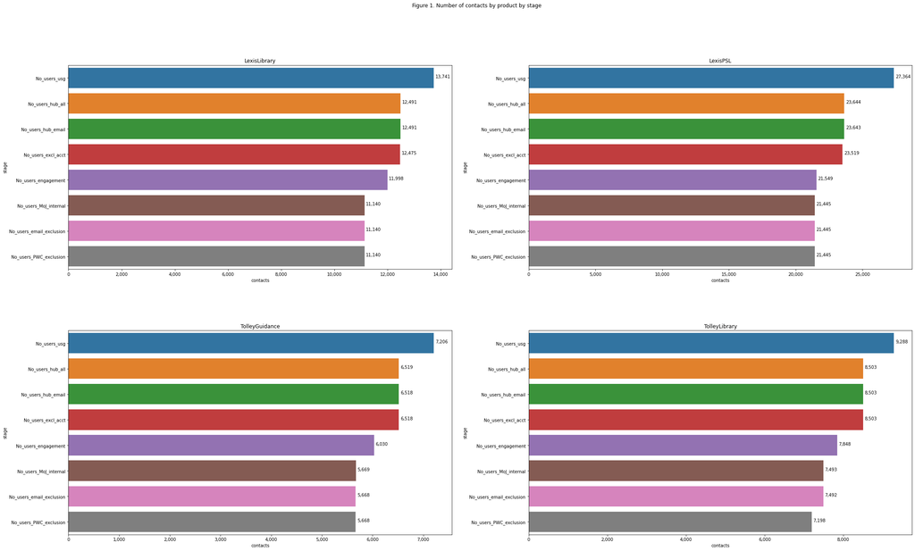

### Funnel view by product by number of users dropped out

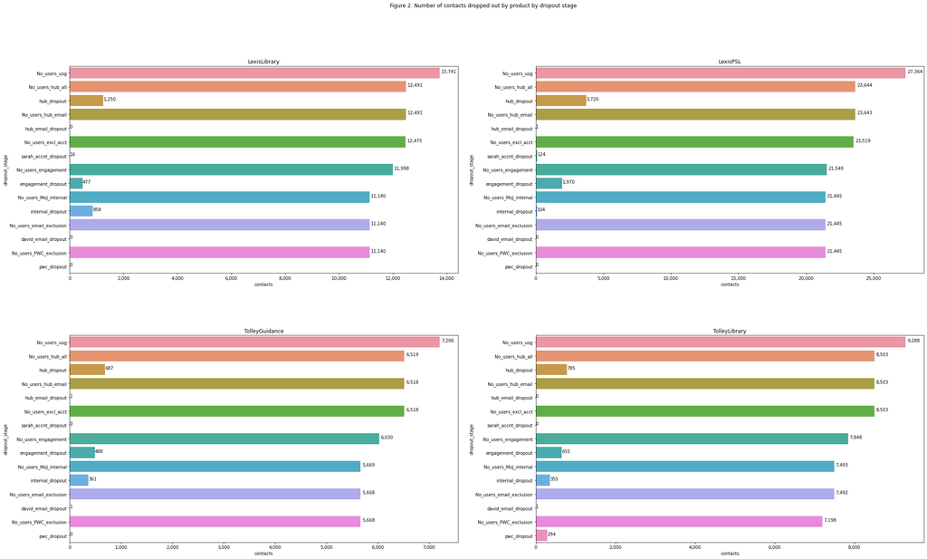

## Summary

Number of emails per person

Number of people getting 1,2 or 3 surveys (only other public customers would have 3 surveys - 1 legal 2 tax)

Number of surveys by people by survey

### General checks

- expect to have one email per contact/user
- expect to have one survey sent out per contact/user per product

```
Number of emails per contact: 1
```

```
Number of emails per contact per product: 1
```

### Summary stats

- Number of contacts/users receiving surveys by product
- Survey Penetration - by segments, how many people will receive 1, 2 or 3 surveys

Table 19. Number of contacts receiving NPS surveys by product

|  | product | number_of_contacts |
| --- | --- | --- |
| 0 | LexisLibrary | 11,140 |
| 1 | LexisPSL | 21,445 |
| 2 | TolleyGuidance | 5,668 |
| 3 | TolleyLibrary | 7,198 |

Table 20. NPS survey penetration

|  | number_of_surveys | number_of_contacts_in_Corporate | number_of_contacts_in_Legal | number_of_contacts_in_Public Sector | number_of_contacts_in_Tax |
| --- | --- | --- | --- | --- | --- |
| 0 | 3 | 0 | 0 | 20 | 0 |
| 1 | 2 | 0 | 0 | 367 | 3,311 |
| 2 | 1 | 2,429 | 25,695 | 5,503 | 4,408 |